# program choice

Adhil

2022-06-26

## Introducion

Choice of students in learning learning prog and their performance is observed here This includes the economic condition their performance and other privilages

## Nature of Variables

- x - integer defines serial numbers
- id - integer The variable which gives the student identity code
- Gender - factor The type of students whether they are male or female
- ses - factor Social economic status of studens low , middle or high
- schtyp - factor The school type which the students have chosen public or private
- prog - factor The type of program the student has enrolled in
- read - integer The marks obtained by students in reading assessment
- write - integer The marks scored by an individual in a writing assessment
- math - integer The marks scored by students in a math test
- science - integer The score of students in science
- socst - integer The score of students in social srudies
- honors - factor with binomial levels enrolled or not enrolled
- awards - Factor with polychotomous nature
- cid - Factor with polychotomous nature

## Information obtained

- Students who come from good socio-economic background are good at scoring high marks
- Some male candidates score high marks however the students of good social status are the majority who more marks
- Female students are better than male students in all subjects compared to male students

## Science performance

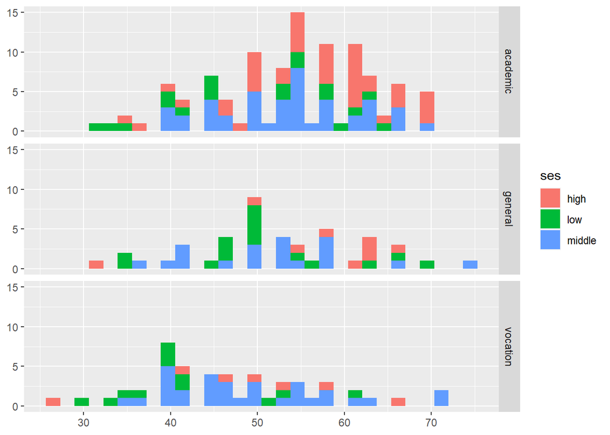

```r
macros = ggplot(choisir1, aes(science,fill=ses)) +
  geom_histogram() +
  xlab(NULL) +
  ylab(NULL)+ facet_grid(prog~.)
macros
```

```r
library(kableExtra)

c1[upper.tri(c1,diag = FALSE)]<-" "
diag(c1)=""
kable(rbind(c1)) %>%  kable_styling()
```

|  | X | id | read | write | math | science | socst |
| --- | --- | --- | --- | --- | --- | --- | --- |
| X |  |  |  |  |  |  |  |
| id | 0.266633165829146 |  |  |  |  |  |  |
| read | 0.854539147613318 | 0.148620290142807 |  |  |  |  |  |
| write | 0.822490140855985 | 0.186688302800909 | 0.596776479088045 |  |  |  |  |
| math | 0.853020444780418 | 0.219233728448951 | 0.66228012515586 | 0.617449264485492 |  |  |  |
| science | 0.834826684786762 | 0.321401521510098 | 0.630157870118315 | 0.570441636240646 | 0.630733160146213 |  |  |
| socst | 0.658233673847299 | 0.183305221771515 | 0.621484272388714 | 0.604793223526324 | 0.54448030452783 | 0.465106004142268 |  |

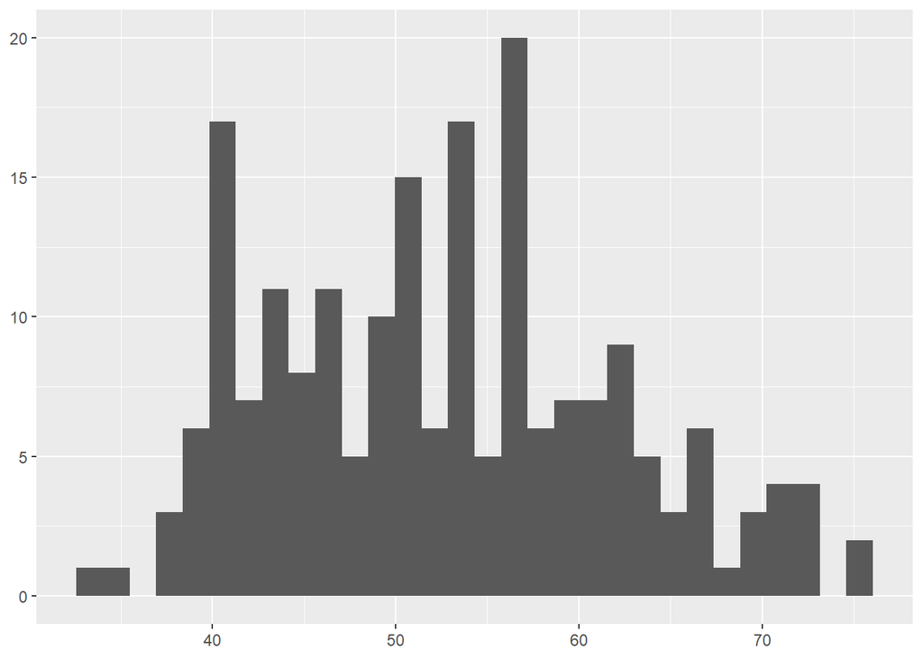

```r
p0=ggplot(choisir1, aes(math)) +
  geom_histogram() +
  xlab(NULL) +
  ylab(NULL)

p0
```

## Inference

- The percentage of female students who are good at academics are comparatively a little higher than the male candidates
- The public and the private school performance in Math is same
- The career choice of students is evenly distributed

[figure not shown]

```r
PL4=ggplot(choisir1, aes(x=math,y=science,color=schtyp))+
  geom_point()+
  xlab("Math")+
  ylab("Awards")+
  facet_grid(ses~Gender+honors,
             scales = "free",space="free")+
  theme(legend.position = "bottom")+
  scale_color_manual(values=c("pink","black",
                              "brown","green"))
PL4
```

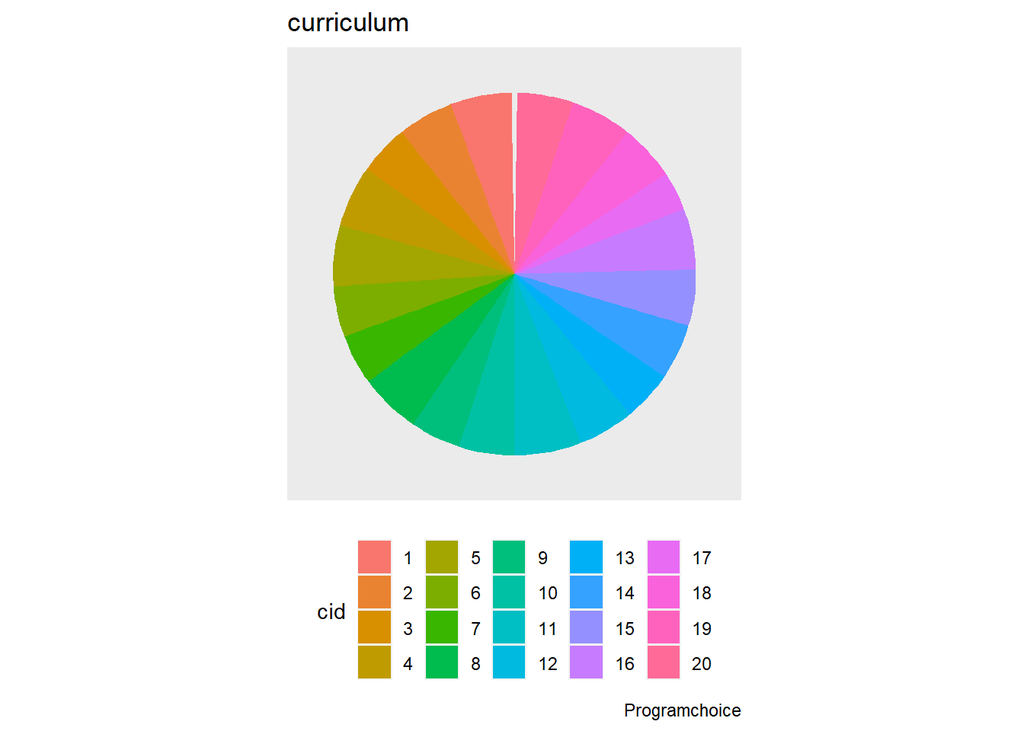

```r
bla1 = ggplot(choisir1,
      aes(x = factor(""), fill = cid) ) +
  geom_bar() +
  coord_polar(theta = "y") +
  scale_x_discrete("")+
  scale_y_discrete("")+
  theme(axis.ticks=element_blank(),
        axis.title=element_blank(),
        axis.text.y=element_blank(),
        axis.text.x=element_blank(),
        panel.grid  = element_blank(),
        legend.position = "bottom")+
  labs(title = "curriculum",
       caption="Programchoice")
bla1
```